# R Notebook

REFERENCES: http://stackoverflow.com/questions/1330989/rotating-and-spacing-axis-labels-in-ggplot2 http://stackoverflow.com/questions/30057765/histogram-ggplot-show-count-label-for-each-bin-for-each-category

```r
library(ggplot2)
```

# Functions

The following function is the function which will be used to get the mode of the data

```r
mymode <- function(x){
  xtable <- table(x)
  idx <- xtable == max(xtable)
  names(xtable)[idx]
}
```

# Read in the data from the csv file

```r
churn_data <- read.csv("./eurocomPHONEchurners.csv")
```

First thing to do is to print out the data summary.

```r
summary(churn_data)
```

```
##     CUST_ID         AREA_CODE     MINUTES_CURR_MONTH MINUTES_PREV_MONTH
##  Min.   :   1.0   Min.   :10040   Min.   :    1.0    Min.   :    0.0
##  1st Qu.: 517.5   1st Qu.:15563   1st Qu.:   33.0    1st Qu.:   15.0
##  Median :1035.0   Median :21750   Median :  105.0    Median :   98.0
##  Mean   :1035.1   Mean   :29816   Mean   :  747.7    Mean   :  863.9
##  3rd Qu.:1552.5   3rd Qu.:45987   3rd Qu.:  555.0    3rd Qu.:  444.0
##  Max.   :2070.0   Max.   :55166   Max.   :14000.0    Max.   :16754.0
##
##  MINUTES_3MONTHS_AGO    CUST_MOS     LONGDIST_FLAG    CALLWAITING_FLAG
##  Min.   :    0       Min.   : 1.00   Min.   :0.0000   Min.   :0.0000
##  1st Qu.:   29       1st Qu.: 6.00   1st Qu.:0.0000   1st Qu.:0.0000
##  Median :   97       Median :11.00   Median :1.0000   Median :0.0000
##  Mean   :  453       Mean   :16.05   Mean   :0.5649   Mean   :0.4346
##  3rd Qu.:  598       3rd Qu.:26.00   3rd Qu.:1.0000   3rd Qu.:1.0000
##  Max.   :12456       Max.   :50.00   Max.   :1.0000   Max.   :1.0000
##  NA's   :3           NA's   :3
##    NUM_LINES     VOICEMAIL_FLAG    MOBILE_PLAN     CONVERGENT_BILLING
##  Min.   :1.000   Min.   :0.0000   Min.   :0.0000   No :1241
##  1st Qu.:1.000   1st Qu.:0.0000   1st Qu.:0.0000   Yes: 830
##  Median :1.000   Median :1.0000   Median :0.0000
##  Mean   :1.391   Mean   :0.5654   Mean   :0.3477
##  3rd Qu.:2.000   3rd Qu.:1.0000   3rd Qu.:1.0000
##  Max.   :3.000   Max.   :1.0000   Max.   :1.0000
##
##  GENDER       INCOME               PHONE_PLAN          EDUCATION
##  F: 731   Min.   : 17000                :   4               :  8
##  M:1340   1st Qu.: 46000   Euro-Zone    :  59   Bachelors   :400
##           Median : 75000   International:1067   High School :  3
##           Mean   : 85784   National     : 671   Masters     :330
##           3rd Qu.: 98000   Promo_plan   : 270   PhD         :410
##           Max.   :320000                        Post Primary:829
##                                                 Primary     : 91
##  TOT_MINUTES_USAGE CHURNER
##  Min.   :    0     no :1021
##  1st Qu.:  116     yes:1050
##  Median :  264
##  Mean   : 2040
##  3rd Qu.: 1677
##  Max.   :36237
##  NA's   :4
```

# Preprocess the data

## Identify duplicate values

ref: http://www.cookbook-r.com/Manipulating_data/Finding_and_removing_duplicate_records/

```r
churn_data[duplicated(churn_data$CUST_ID), ]
```

```
##     CUST_ID AREA_CODE MINUTES_CURR_MONTH MINUTES_PREV_MONTH
## 152     246     10040                  2                  0
##     MINUTES_3MONTHS_AGO CUST_MOS LONGDIST_FLAG CALLWAITING_FLAG NUM_LINES
## 152                   0        1             0                0         1
##     VOICEMAIL_FLAG MOBILE_PLAN CONVERGENT_BILLING GENDER INCOME PHONE_PLAN
## 152              1           0                 No      F  29000   National
##        EDUCATION TOT_MINUTES_USAGE CHURNER
## 152 Post Primary                 0      no
```

## Remove the duplicates

```r
churn_data <- churn_data[!duplicated(churn_data$CUST_ID), ]
```

```r
nrow(churn_data)
```

```
## [1] 2070
```

## Identify null values

The summary data can be used to identify the columns which contain null values.

The columns with null values are:

- MINUTES_3MONTHS_AGO (3 records)
- CUST_MOS (3 records)
- TOT_MINUTES_USAGE (4 records)
- PHONE_PLAN (4 records)
- EDUCATION (8 records)

## Addressing the issues of the missing values.

For the numeric values they will be replaced with median value for the columns

### MINUTES_3MONTHS_AGO

```r
median(churn_data$MINUTES_3MONTHS_AGO, na.rm = TRUE)
```

```
## [1] 97
```

```r
MINUTES_3MONTHS_AGO_median <- median(churn_data$MINUTES_3MONTHS_AGO, na.rm = TRUE)
```

```r
churn_data$MINUTES_3MONTHS_AGO[is.na(churn_data$MINUTES_3MONTHS_AGO)] <- MINUTES_3MONTHS_AGO_median
```

### CUST_MOS

```r
median(churn_data$CUST_MOS, na.rm = TRUE)
```

```
## [1] 11
```

```r
CUST_MOS_median <- median(churn_data$CUST_MOS, na.rm = TRUE)
```

```r
churn_data$CUST_MOS[is.na(churn_data$CUST_MOS)] <- CUST_MOS_median
```

### TOT_MINUTES_USAGE

```r
median(churn_data$TOT_MINUTES_USAGE, na.rm = TRUE)
```

```
## [1] 264
```

```r
TOT_MINUTES_USAGE_median <- median(churn_data$TOT_MINUTES_USAGE, na.rm = TRUE)
```

```r
churn_data$TOT_MINUTES_USAGE[is.na(churn_data$TOT_MINUTES_USAGE)] <- TOT_MINUTES_USAGE_median
```

### PHONE_PLAN

The first thing to do was to create a data frame which is comprised of the gender and phone plan

```r
  phone_plan_gender_subset <- data.frame(churn_data$PHONE_PLAN, churn_data$GENDER)
```

The data frame is then filtered again so it just contains data for record for male records

```r
  phone_plan_male_subset <- phone_plan_gender_subset[phone_plan_gender_subset$churn_data.GENDER == 'M', 1]
```

```r
  phone_plan_male_subset[1:10]
```

```
##  [1] International International International Promo_plan    National
##  [6] National      International National      National      International
## Levels:  Euro-Zone International National Promo_plan
```

The mode of the phone plan is stored for male records

```r
  print(phone_plan_male_mode <- mymode(phone_plan_male_subset))
```

```
## [1] "International"
```

The data frame is then filtered again so it just contains data for record for female records

```r
  phone_plan_female_subset <- phone_plan_gender_subset[phone_plan_gender_subset$churn_data.GENDER == 'F', 1]
```

```r
  phone_plan_female_subset[1:10]
```

```
##  [1] National      International International National      International
##  [6] International National      International National      International
## Levels:  Euro-Zone International National Promo_plan
```

```r
  print(phone_plan_female_mode <- mymode(phone_plan_female_subset))
```

```
## [1] "International"
```

We then find the indexes of the phone plan records with empty values

```r
  no_phone_plans <- which(churn_data$PHONE_PLAN == "")
```

```r
for (index in no_phone_plans)
{
  if (churn_data$GENDER[index] == 'M')
  {
    churn_data$PHONE_PLAN[index] <- phone_plan_male_mode
  }
  else
  {
    churn_data$PHONE_PLAN[index] <- phone_plan_female_mode
  }
}
```

```r
  churn_data$PHONE_PLAN[no_phone_plans]
```

```
## [1] International International International International
## Levels:  Euro-Zone International National Promo_plan
```

```r
churn_data$PHONE_PLAN <- droplevels(churn_data$PHONE_PLAN)
```

```r
summary(churn_data$PHONE_PLAN)
```

```
##     Euro-Zone International      National    Promo_plan
##            59          1071           670           270
```

### EDUCATION

The first thing to do was to create a data frame which is comprised of the gender and education

```r
  education_gender_subset <- data.frame(churn_data$EDUCATION, churn_data$GENDER)
```

The data frame is then filtered again so it just contains data for record for male records

```r
  no_education_male_subset <- education_gender_subset[education_gender_subset$churn_data.GENDER == 'M', 1]
```

```r
  no_education_male_mode <- mymode(no_education_male_subset)
```

```r
  no_education_male_mode
```

```
## [1] "Post Primary"
```

The data frame is then filtered again so it just contains data for record for female records

```r
  no_education_female_subset <- education_gender_subset[education_gender_subset$churn_data.GENDER == 'F', 1]
```

```r
  no_education_female_mode <- mymode(no_education_female_subset)
```

```r
  no_education_female_mode
```

```
## [1] "Bachelors"
```

```r
  no_education <- which(churn_data$EDUCATION == "")
```

```r
for (index in no_education)
{
  if (churn_data$GENDER[index] == 'M')
  {
    churn_data$EDUCATION[index] <- no_education_male_mode
  }
  else
  {
    churn_data$EDUCATION[index] <- no_education_female_mode
  }
}
```

```r
churn_data$EDUCATION[no_education]
```

```
## [1] Post Primary Bachelors    Post Primary Post Primary Post Primary
## [6] Post Primary Bachelors    Bachelors
## Levels:  Bachelors High School Masters PhD Post Primary Primary
```

```r
churn_data$EDUCATION <- droplevels(churn_data$EDUCATION)
```

```r
summary(churn_data)
```

```
##     CUST_ID         AREA_CODE     MINUTES_CURR_MONTH MINUTES_PREV_MONTH
##  Min.   :   1.0   Min.   :10040   Min.   :    1.0    Min.   :    0.0
##  1st Qu.: 518.2   1st Qu.:15563   1st Qu.:   33.0    1st Qu.:   15.0
##  Median :1035.5   Median :21750   Median :  105.0    Median :   98.0
##  Mean   :1035.5   Mean   :29826   Mean   :  748.1    Mean   :  864.3
##  3rd Qu.:1552.8   3rd Qu.:45987   3rd Qu.:  555.0    3rd Qu.:  444.0
##  Max.   :2070.0   Max.   :55166   Max.   :14000.0    Max.   :16754.0
##  MINUTES_3MONTHS_AGO    CUST_MOS     LONGDIST_FLAG    CALLWAITING_FLAG
##  Min.   :    0.0     Min.   : 1.00   Min.   :0.0000   Min.   :0.0000
##  1st Qu.:   29.0     1st Qu.: 6.00   1st Qu.:0.0000   1st Qu.:0.0000
##  Median :   97.0     Median :11.00   Median :1.0000   Median :0.0000
##  Mean   :  452.7     Mean   :16.05   Mean   :0.5652   Mean   :0.4348
##  3rd Qu.:  598.0     3rd Qu.:26.00   3rd Qu.:1.0000   3rd Qu.:1.0000
##  Max.   :12456.0     Max.   :50.00   Max.   :1.0000   Max.   :1.0000
##    NUM_LINES     VOICEMAIL_FLAG    MOBILE_PLAN     CONVERGENT_BILLING
##  Min.   :1.000   Min.   :0.0000   Min.   :0.0000   No :1240
##  1st Qu.:1.000   1st Qu.:0.0000   1st Qu.:0.0000   Yes: 830
##  Median :1.000   Median :1.0000   Median :0.0000
##  Mean   :1.391   Mean   :0.5652   Mean   :0.3478
##  3rd Qu.:2.000   3rd Qu.:1.0000   3rd Qu.:1.0000
##  Max.   :3.000   Max.   :1.0000   Max.   :1.0000
##  GENDER       INCOME               PHONE_PLAN          EDUCATION
##  F: 730   Min.   : 17000   Euro-Zone    :  59   Bachelors   :403
##  M:1340   1st Qu.: 46000   International:1071   High School :  3
##           Median : 75000   National     : 670   Masters     :330
##           Mean   : 85812   Promo_plan   : 270   PhD         :410
##           3rd Qu.: 98000                        Post Primary:833
##           Max.   :320000                        Primary     : 91
##  TOT_MINUTES_USAGE CHURNER
##  Min.   :    0     no :1020
##  1st Qu.:  116     yes:1050
##  Median :  264
##  Mean   : 2037
##  3rd Qu.: 1677
##  Max.   :36237
```

```r
churn_data$INCOME <- cut(churn_data$INCOME, breaks=c(0,38000,88000,Inf), right = FALSE, labels=c("low income","medium income","high income"))
```

# Predictor Information

## CUST_ID

Unique Account Number that identifies an account holder

| Predictor | CUST_ID |
| --- | --- |
| attribute type | Nominal ` |
| Max | 2070 |
| Min | 1 |

## AREA_CODE

Geographical area account holder resides

| Predictor | AREA_CODE |
| --- | --- |
| attribute type | Nominal |
| %Missing Values | 0% |
| Mode | 10040, 15563, 21750, 36785, 45987 |

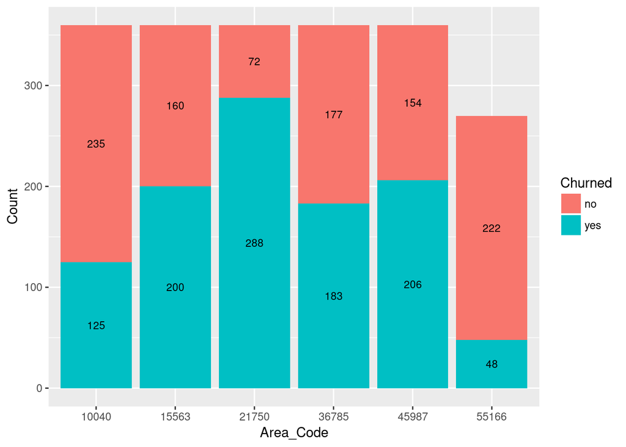

```r
plot_data <- data.frame(table(churn_data$AREA_CODE, churn_data$CHURNER))
colnames(plot_data) <- c("Area_Code", "Churned", "Count" )
ggplot(data=plot_data, aes(x = Area_Code, y = Count, fill = Churned, label = Count)) +
  geom_bar(stat = "identity") +
  geom_text(size = 3, position = position_stack(vjust = 0.5))
```

## LONGDIST_FLAG

Whether has signed up for the off-peak long distance call package

Predictor

LONGDIST_FLAG

attribute type

Nominal

%Missing Values

[output not shown]

Mode

1

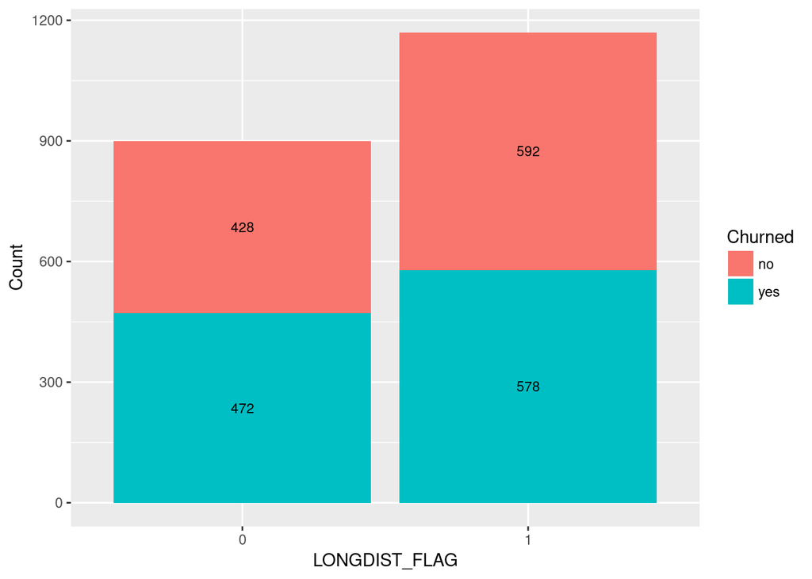

```r
plot_data <- data.frame(table(churn_data$LONGDIST_FLAG, churn_data$CHURNER))
colnames(plot_data) <- c("LONGDIST_FLAG", "Churned", "Count" )
ggplot(data=plot_data, aes(x = LONGDIST_FLAG, y = Count, fill = Churned, label = Count)) +
  geom_bar(stat = "identity") +
  geom_text(size = 3, position = position_stack(vjust = 0.5))
```

## CALLWAITING_FLAG

Whether the customer has call waiting

| Predictor | CALLWAITING_FLAG |
| --- | --- |
| attribute type | Nominal |
| %Missing Values | 0% |
| Mode | 0 |

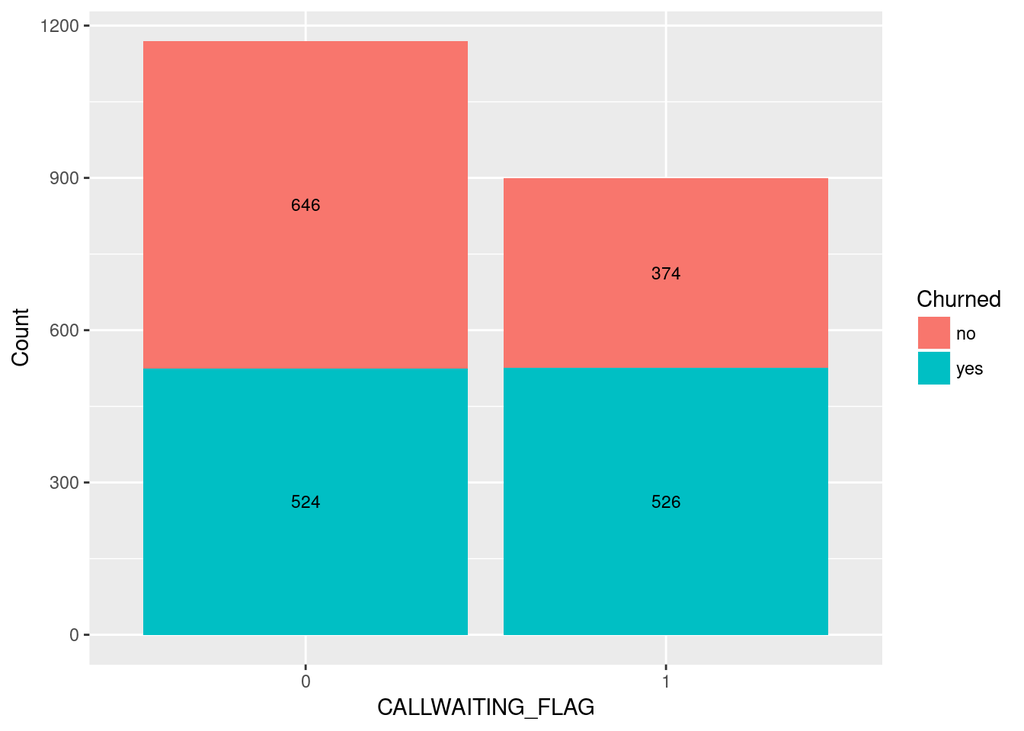

```r
plot_data <- data.frame(table(churn_data$CALLWAITING_FLAG, churn_data$CHURNER))
colnames(plot_data) <- c("CALLWAITING_FLAG", "Churned", "Count")
ggplot(data=plot_data, aes(x = CALLWAITING_FLAG, y = Count, fill = Churned, label = Count)) +
  geom_bar(stat = "identity") +
  geom_text(size = 3, position = position_stack(vjust = 0.5))
```

## VOICEMAIL_FLAG

Whether the customer has voice mail

| Predictor | VOICEMAIL_FLAG |
| --- | --- |
| attribute type | Nominal |
| %Missing Values | 0% |
| Mode | 1 |

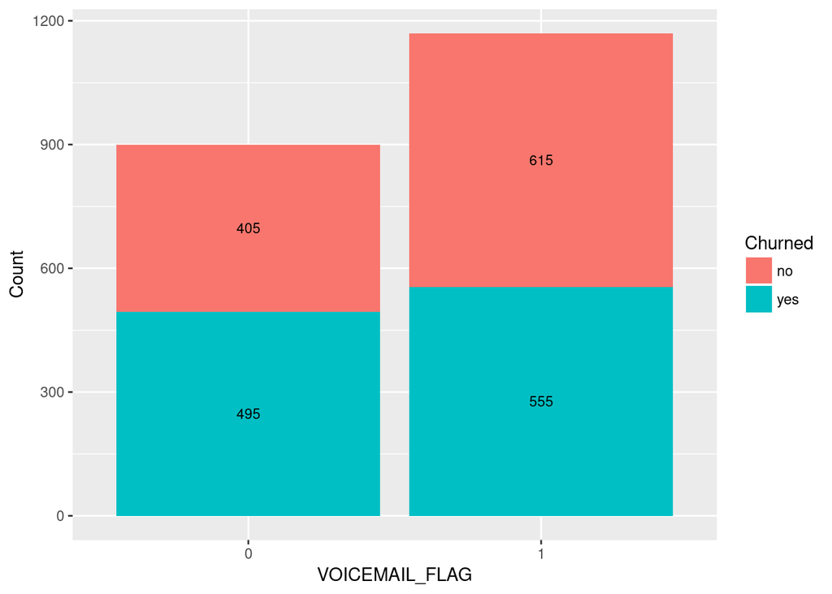

```r
plot_data <- data.frame(table(churn_data$VOICEMAIL_FLAG, churn_data$CHURNER))
colnames(plot_data) <- c("VOICEMAIL_FLAG", "Churned", "Count" )
ggplot(data=plot_data, aes(x = VOICEMAIL_FLAG, y = Count, fill = Churned, label = Count)) +
  geom_bar(stat = "identity") +
  geom_text(size = 3, position = position_stack(vjust = 0.5))
```

## MOBILE_PLAN

Has the customer signed up to the mobile phone plan

| Predictor | MOBILE_PLAN |
| --- | --- |
| attribute type | Nominal |
| %Missing Values | 0% |
| Mode | 0 |

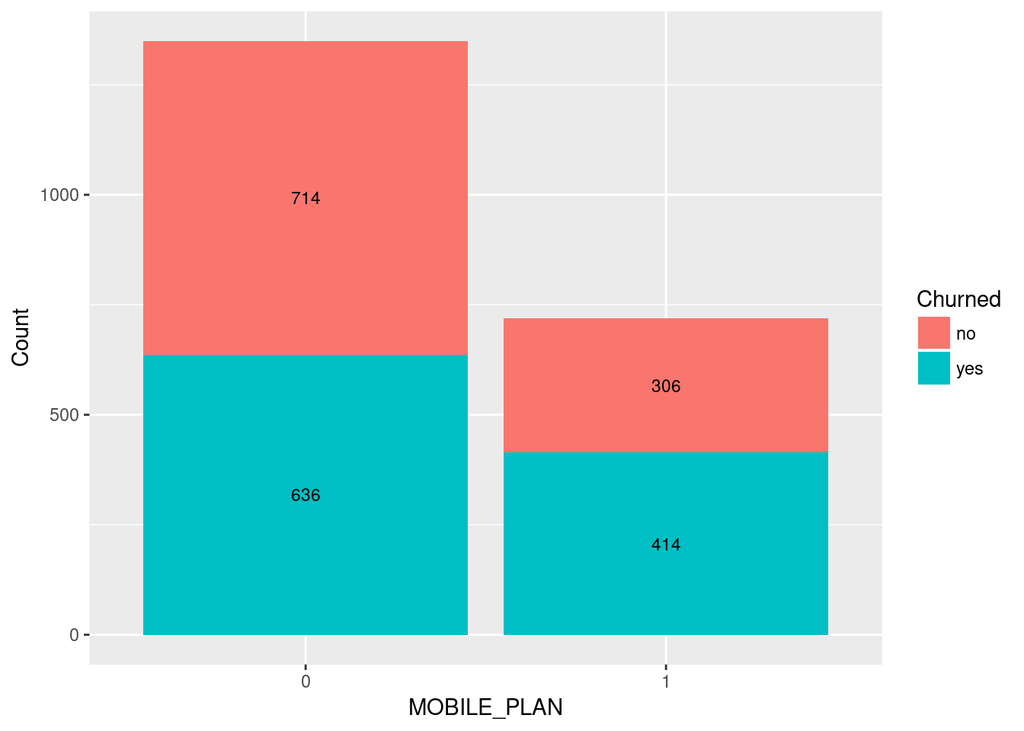

```r
plot_data <- data.frame(table(churn_data$MOBILE_PLAN, churn_data$CHURNER))
colnames(plot_data) <- c("MOBILE_PLAN", "Churned", "Count" )
ggplot(data=plot_data, aes(x = MOBILE_PLAN, y = Count, fill = Churned, label = Count)) +
  geom_bar(stat = "identity") +
  geom_text(size = 3, position = position_stack(vjust = 0.5))
```

## CONVERGENT_BILLING

All service charges consolidated onto one bill

| Predictor | CONVERGENT_BILLING |
| --- | --- |
| attribute type | Nominal |
| %Missing Values | 0% |
| Mode | No |

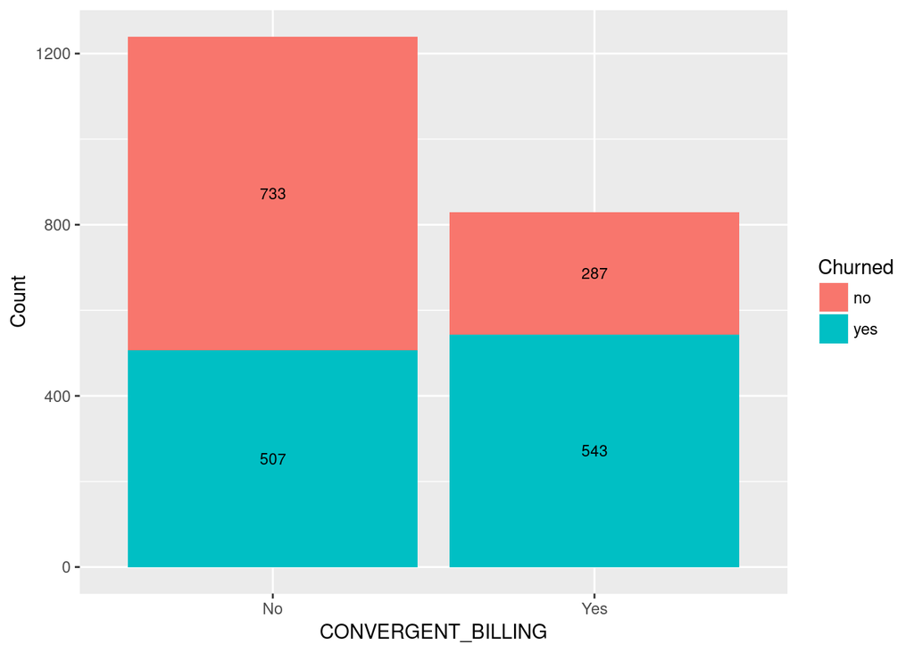

```r
plot_data <- data.frame(table(churn_data$CONVERGENT_BILLING, churn_data$CHURNER))
colnames(plot_data) <- c("CONVERGENT_BILLING", "Churned", "Count" )
ggplot(data=plot_data, aes(x = CONVERGENT_BILLING, y = Count, fill = Churned, label = Count)) +
  geom_bar(stat = "identity") +
  geom_text(size = 3, position = position_stack(vjust = 0.5))
```

## GENDER

Account holder’s gender

| Predictor | GENDER |
| --- | --- |
| attribute type | Nominal |
| %Missing Values | 0% |
| Mode | M |

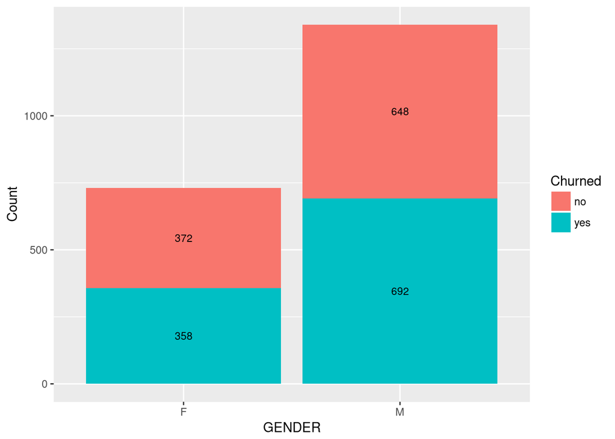

```r
plot_data <- data.frame(table(churn_data$GENDER, churn_data$CHURNER))
colnames(plot_data) <- c("GENDER", "Churned", "Count" )
ggplot(data=plot_data, aes(x = GENDER, y = Count, fill = Churned, label = Count)) +
  geom_bar(stat = "identity") +
  geom_text(size = 3, position = position_stack(vjust = 0.5))
```

## INCOME

Account holder’s annual income (€)

| Predictor | INCOME |
| --- | --- |
| attribute type | Ordinal |
| %Missing Values | 0% |
| Mode | medium income |

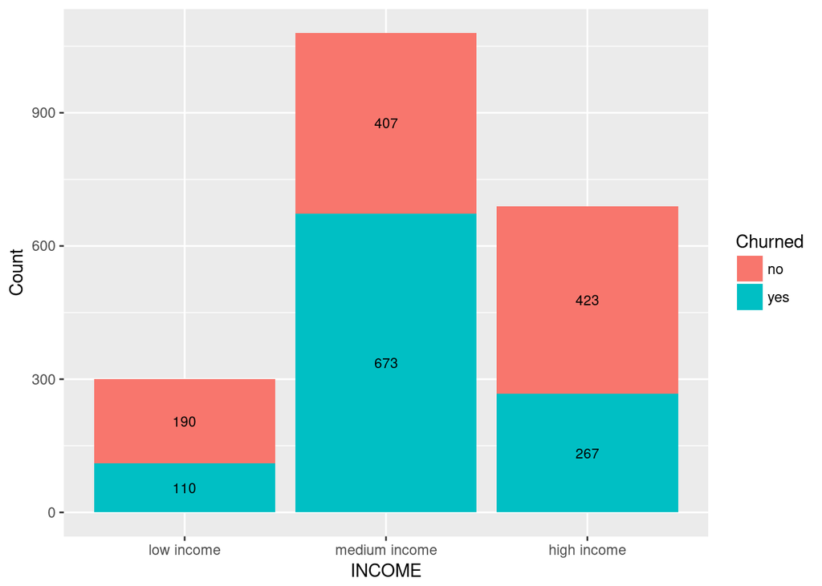

```r
plot_data <- data.frame(table(churn_data$INCOME, churn_data$CHURNER))
colnames(plot_data) <- c("INCOME", "Churned", "Count" )
ggplot(data=plot_data, aes(x = INCOME, y = Count, fill = Churned, label = Count)) +
  geom_histogram(stat = "identity") +
  geom_text(size = 3, position = position_stack(vjust = 0.5))
```

## PHONE_PLAN

The phone plan the customer has signed up for national, euro-zone, international (outside Euro-zone) and promo_plan (signed up to the promotional plan)

| Predictor | PHONE_PLAN |
| --- | --- |
| attribute type | Nominal |
| %Missing Values | 0% |
| Mode | International |

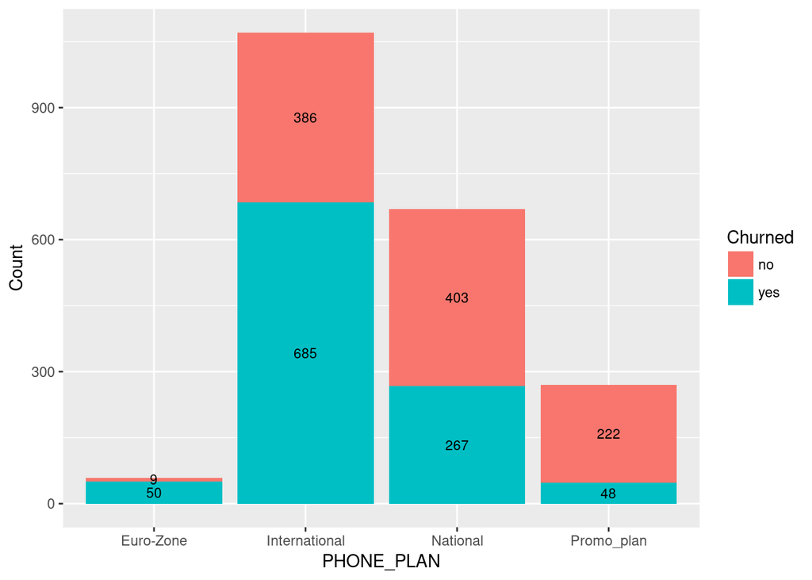

```r
plot_data <- data.frame(table(churn_data$PHONE_PLAN, churn_data$CHURNER))
colnames(plot_data) <- c("PHONE_PLAN", "Churned", "Count" )
ggplot(data=plot_data, aes(x = PHONE_PLAN, y = Count, fill = Churned, label = Count)) +
  geom_bar(stat = "identity") +
  geom_text(size = 3, position = position_stack(vjust = 0.5))
```